# STAT 508 Final Project EDA

Callum Arnold

# Set Up

```r
library(tidyverse)
library(here)
library(hrbrthemes)
library(janitor)
library(corrplot)
library(skimr)

RNGkind(sample.kind = "Rounding")
set.seed(1)

theme_set(theme_ipsum())
```

```r
credit <- as_tibble(read_csv(here("data", "creditcard.csv")))
```

# EDA

```r
head(credit)
```

| Time | V1 | V2 | V3 | V4 | V5 | V6 | V7 | V8 | V9 | V10 | V11 | V12 | V13 | V14 | V15 | V16 | V17 | V18 | V19 | V20 | V21 | V22 | V23 | V24 | V25 | V26 | V27 | V28 | Amount | … |
| --- | --- | --- | --- | --- | --- | --- | --- | --- | --- | --- | --- | --- | --- | --- | --- | --- | --- | --- | --- | --- | --- | --- | --- | --- | --- | --- | --- | --- | --- | --- |
| 0 | -1.3598071 | -0.07278117 | 2.5363467 | 1.3781552 | -0.33832077 | 0.46238778 | 0.23959855 | 0.09869790 | 0.3637870 | 0.09079417 | -0.5515995 | -0.61780086 | -0.9913898 | -0.3111694 | 1.4681770 | -0.4704005 | 0.20797124 | 0.02579058 | 0.40399296 | 0.25141210 | -0.018306778 | 0.277837576 | -0.11047391 | 0.06692807 | 0.1285394 | -0.1891148 | 0.133558377 | -0.02105305 | 149.62 | … |
| 0 | 1.1918571 | 0.26615071 | 0.1664801 | 0.4481541 | 0.06001765 | -0.08236081 | -0.07880298 | 0.08510165 | -0.2554251 | -0.16697441 | 1.6127267 | 1.06523531 | 0.4890950 | -0.1437723 | 0.6355581 | 0.4639170 | -0.11480466 | -0.18336127 | -0.14578304 | -0.06908314 | -0.225775248 | -0.638671953 | 0.10128802 | -0.33984648 | 0.1671704 | 0.1258945 | -0.008983099 | 0.01472417 | 2.69 | … |
| 1 | -1.3583541 | -1.34016307 | 1.7732093 | 0.3797796 | -0.50319813 | 1.80049938 | 0.79146096 | 0.24767579 | -1.5146543 | 0.20764287 | 0.6245015 | 0.06608369 | 0.7172927 | -0.1659459 | 2.3458649 | -2.8900832 | 1.10996938 | -0.12135931 | -2.26185710 | 0.52497973 | 0.247998153 | 0.771679402 | 0.90941226 | -0.68928096 | -0.3276418 | -0.1390966 | -0.055352794 | -0.05975184 | 378.66 | … |
| 1 | -0.9662717 | -0.18522601 | 1.7929933 | -0.8632913 | -0.01030888 | 1.24720317 | 0.23760894 | 0.37743587 | -1.3870241 | -0.05495192 | -0.2264873 | 0.17822823 | 0.5077569 | -0.2879237 | -0.6314181 | -1.0596472 | -0.68409279 | 1.96577500 | -1.23262197 | -0.20803778 | -0.108300452 | 0.005273597 | -0.19032052 | -1.17557533 | 0.6473760 | -0.2219288 | 0.062722849 | 0.06145763 | 123.50 | … |
| 2 | -1.1582331 | 0.87773675 | 1.5487178 | 0.4030339 | -0.40719338 | 0.09592146 | 0.59294075 | -0.27053268 | 0.8177393 | 0.75307443 | -0.8228429 | 0.53819555 | 1.3458516 | -1.1196698 | 0.1751211 | -0.4514492 | -0.23703324 | -0.03819479 | 0.80348692 | 0.40854236 | -0.009430697 | 0.798278495 | -0.13745808 | 0.14126698 | -0.2060096 | 0.5022922 | 0.219422230 | 0.21515315 | 69.99 | … |
| 2 | -0.4259659 | 0.96052304 | 1.1411093 | -0.1682521 | 0.42098688 | -0.02972755 | 0.47620095 | 0.26031433 | -0.5686714 | -0.37140720 | 1.3412620 | 0.35989384 | -0.3580907 | -0.1371337 | 0.5176168 | 0.4017259 | -0.05813282 | 0.06865315 | -0.03319379 | 0.08496767 | -0.208253515 | -0.559824796 | -0.02639767 | -0.37142658 | -0.2327938 | 0.1059148 | 0.253844225 | 0.08108026 | 3.67 | … |

## Variable Summary

```r
anyNA(credit)
```

```
[1] FALSE
```

```r
skim(credit)
```

```
── Data Summary ────────────────────────
                           Values
Name                       credit
Number of rows             284807
Number of columns          31
_______________________
Column type frequency:
  numeric                  31
________________________
Group variables            None

── Variable type: numeric ───────────────────────────────────────────────────────────────────────────────────────────────────
   skim_variable n_missing complete_rate      mean         sd      p0        p25         p50         p75      p100 hist
 1 Time                  0             1  9.48e+ 4 47488.        0    54202.     84692       139320.     172792    ▃▇▅▆▇
 2 V1                    0             1  1.17e-15     1.96    -56.4     -0.920      0.0181       1.32        2.45 ▁▁▁▁▇
```

[output cut: 29 more lines]

```r
for (i in 1:ncol(credit)){
  print(summary(credit[, i]))
}
```

```
      Time
 Min.   :     0
 1st Qu.: 54202
 Median : 84692
 Mean   : 94814
 3rd Qu.:139320
 Max.   :172792
       V1
 Min.   :-56.40751
 1st Qu.: -0.92037
 Median :  0.01811
 Mean   :  0.00000
 3rd Qu.:  1.31564
 Max.   :  2.45493
       V2
 Min.   :-72.71573
 1st Qu.: -0.59855
 Median :  0.06549
 Mean   :  0.00000
 3rd Qu.:  0.80372
 Max.   : 22.05773
       V3
 Min.   :-48.3256
 1st Qu.: -0.8904
 Median :  0.1799
 Mean   :  0.0000
 3rd Qu.:  1.0272
 Max.   :  9.3826
       V4
 Min.   :-5.68317
 1st Qu.:-0.84864
 Median :-0.01985
 Mean   : 0.00000
 3rd Qu.: 0.74334
 Max.   :16.87534
       V5
 Min.   :-113.74331
 1st Qu.:  -0.69160
 Median :  -0.05434
 Mean   :   0.00000
```

[output cut: 162 more lines]

```
 Max.   : 33.84781
     Amount
 Min.   :    0.00
 1st Qu.:    5.60
 Median :   22.00
 Mean   :   88.35
 3rd Qu.:   77.17
 Max.   :25691.16
     Class
 Min.   :0.000000
 1st Qu.:0.000000
 Median :0.000000
 Mean   :0.001728
 3rd Qu.:0.000000
 Max.   :1.000000
```

### Distributions

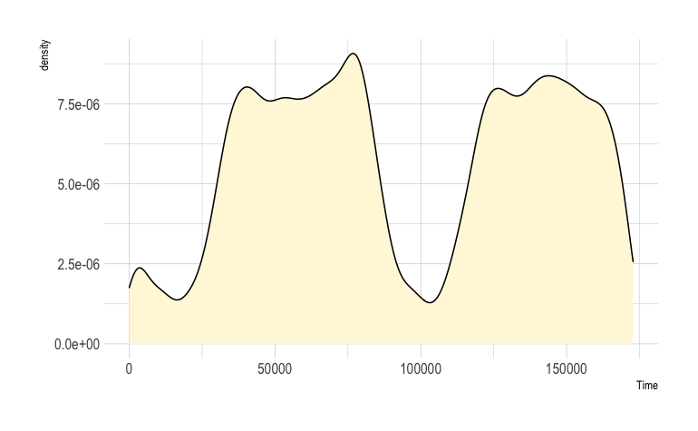

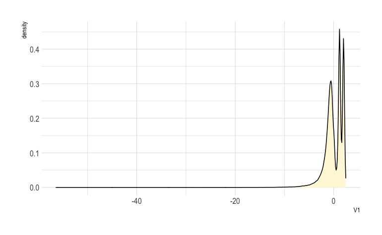

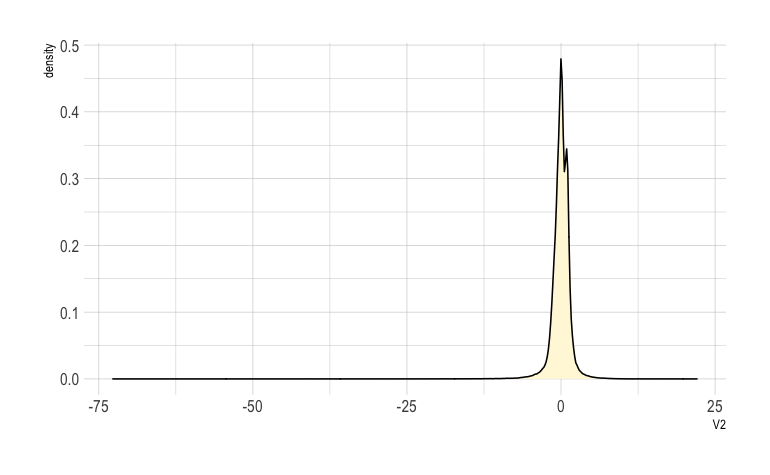

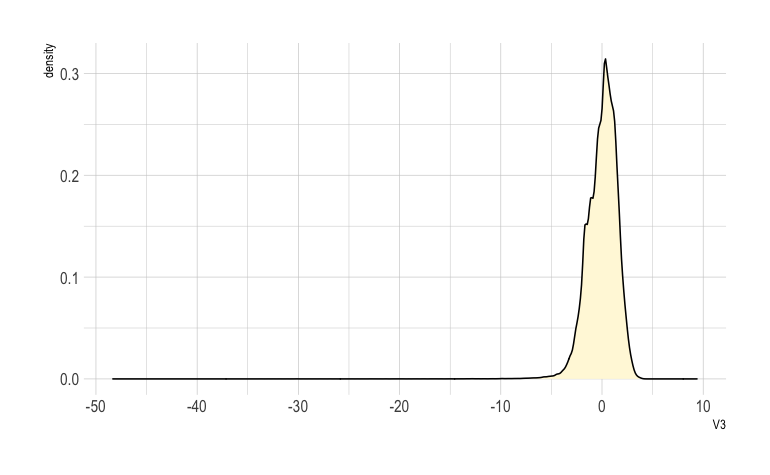

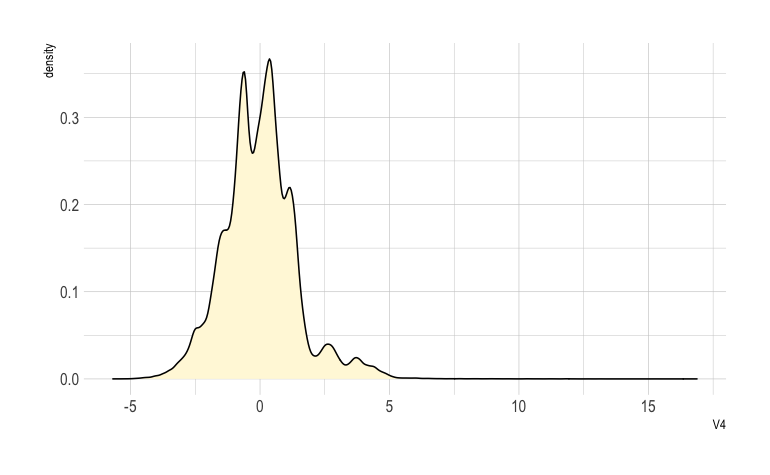

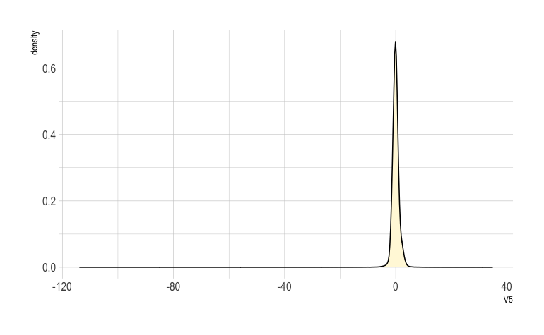

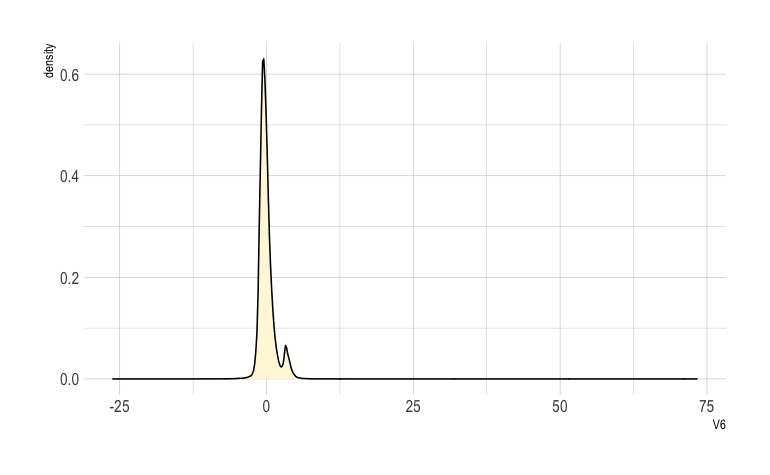

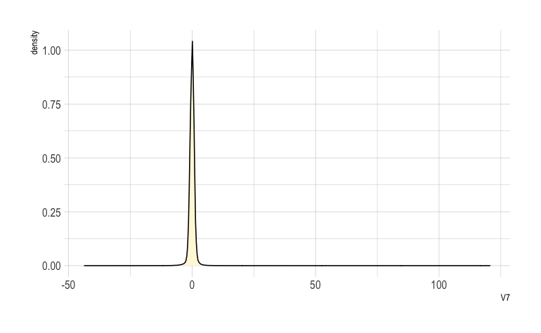

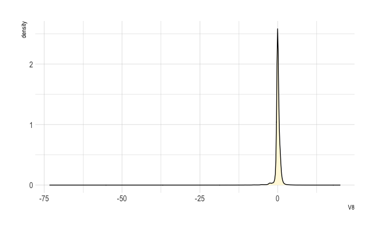

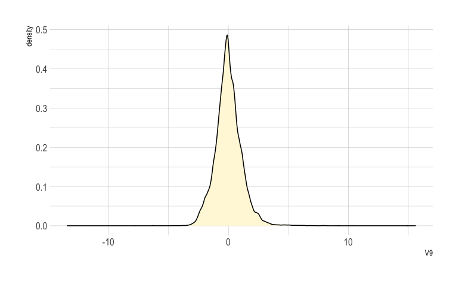

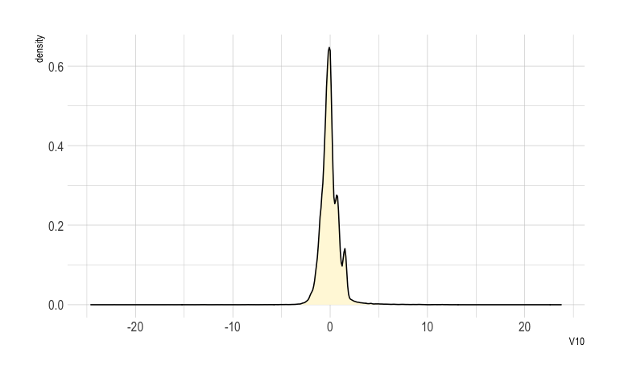

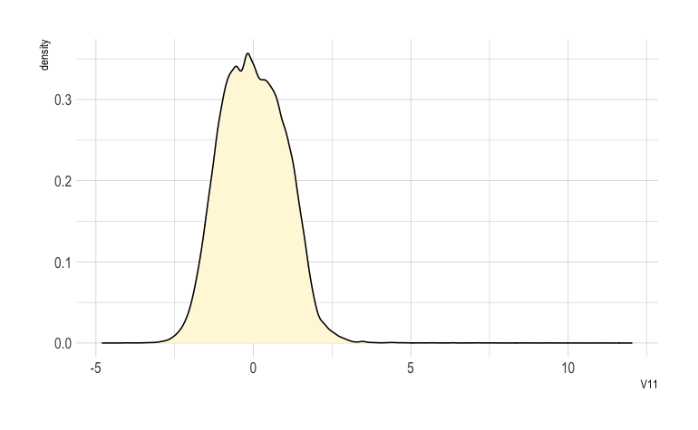

[18 more figures not shown]

```r
for (i in names(credit[, -31])) {
  p <- ggplot(credit, aes_string(x = i)) +
    geom_density(fill = "cornsilk")

  print(p)
}
```

## Relationship with Response

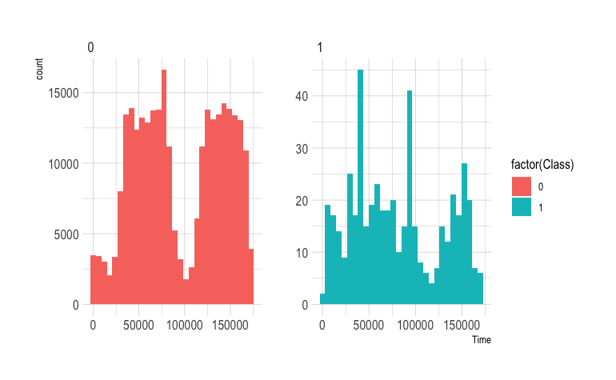

```r
ggplot(data = credit, aes(x = Time, fill = factor(Class))) +
  geom_histogram() +
  facet_wrap(~Class, scales = "free")
```

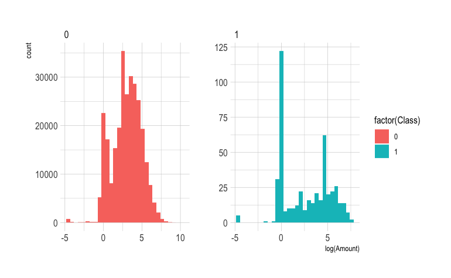

```r
ggplot(data = credit, aes(x = log(Amount), fill = factor(Class))) +
  geom_histogram() +
  facet_wrap(~Class, scales = "free")
```

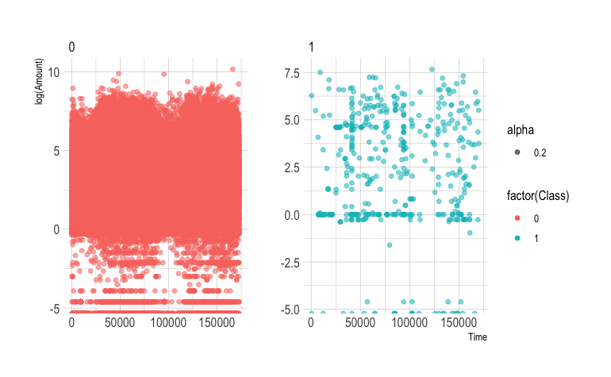

```r
ggplot(data = credit, aes(x = Time, y = log(Amount), alpha = 0.2, color = factor(Class))) +
  geom_point() +
  facet_wrap(~Class, scales = "free")
```

There is a clear skew to the `Amount` variable, so it is worth applying a transformation to the data. As there are values of `0`, we need to add `1` to ensure that we don’t get `Inf` values produced after log transformation.

```r
credit <- credit %>%
  mutate(log_amount = log(Amount + 1))

summary(credit$log_amount)
```

```
   Min. 1st Qu.  Median    Mean 3rd Qu.    Max.
  0.000   1.887   3.135   3.152   4.359  10.154
```

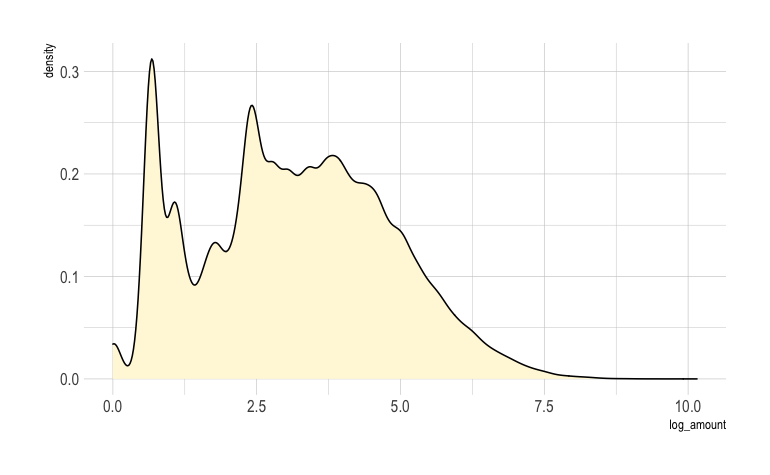

```r
ggplot(credit, aes(x = log_amount)) +
    geom_density(fill = "cornsilk")
```

## Predictor Correlations

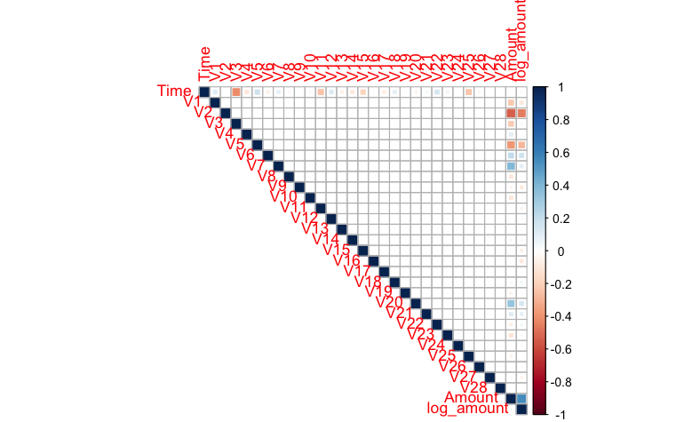

```r
corrplot(cor(credit[, -31]), method = "square", type = "upper")
```

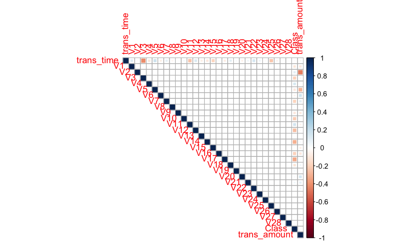

```r
credit %>%
  mutate(
    trans_time = scale(Time, center = TRUE),
    trans_amount = scale(log_amount, center = TRUE)
    ) %>%
  select(trans_time, everything()) %>%
  select(-c(Amount, Time, log_amount)) %>%
  cor() %>%
  corrplot(method = "square", type = "upper")
```

# PCA Importance

Even though we don’t have the original data for a full exploration of the PCs, we can still look at the importance of the individual PCs in explaining the total variance in the data as we know that the variance observed in each PC is equal to its eigenvalue (https://online.stat.psu.edu/stat505/lesson/11/11.2). Therefore we can still calculate the relative proportions of variance explained, without needed the eigenvalue outputs of the standard `prcomp` function.

```r
credit %>%
  select(-c(Time, Amount, log_amount, Class)) %>%
  sapply(var) %>%
  sort(decreasing = TRUE)
```

```
       V1        V2        V3        V4        V5        V6        V7        V8        V9       V10       V11       V12
3.8364893 2.7268200 2.2990292 2.0046838 1.9050810 1.7749463 1.5304006 1.4264789 1.2069925 1.1855938 1.0418551 0.9984034
      V13       V14       V15       V16       V17       V18       V19       V20       V21       V22       V23       V24
0.9905708 0.9189055 0.8378034 0.7678191 0.7213734 0.7025394 0.6626619 0.5943254 0.5395255 0.5266428 0.3899507 0.3668084
      V25       V26       V27       V28
0.2717308 0.2325429 0.1629192 0.1089550
```

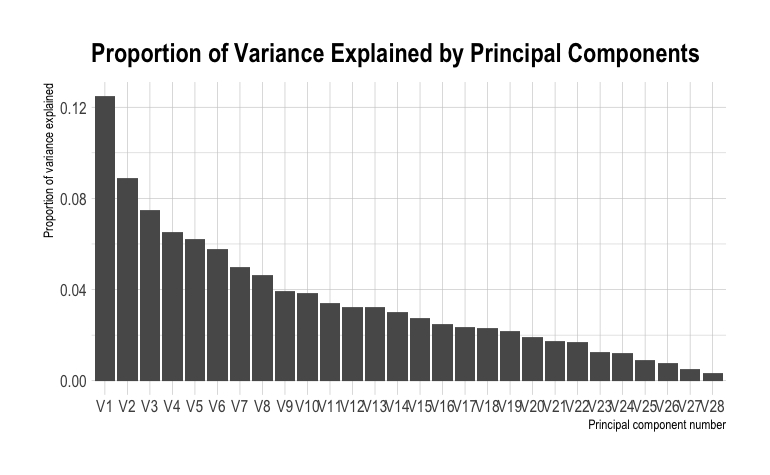

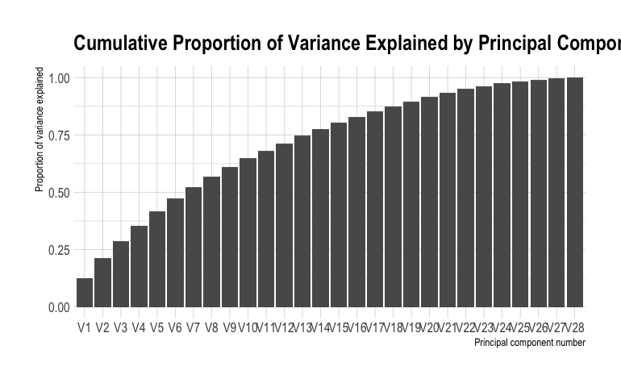